# Summary Table

Chemical Name

Toxicity Characteristics

Exposure Sources

Predicted Intake (mg/kg/d)

Production Volume (millions of lbs/y)

1,1-Dichloroethane

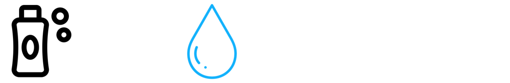

0.1823

100– <1000

1,2,3-Trichloropropane

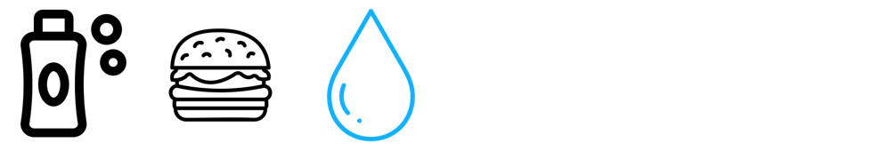

0.5424

1– <20

1,2-Dichloroethane

3.097

30000– <40000

1,2-Dichloropropane

0.4597

100– <1000

1,2-Propylene oxide

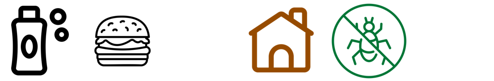

0.1063

1000– <5000

1,3-Dichloropropene

0.4908

20– <100

11-Aminoundecanoic acid

0.9536

1– <20

2,4,6-Tribromophenol

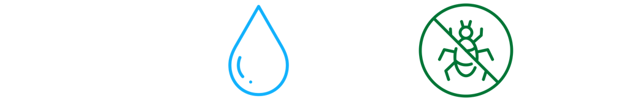

1.112

20– <100

2,4-Dichlorophenol

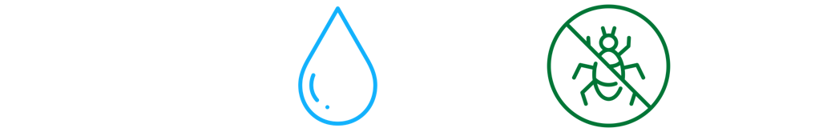

0.8411

20– <100

2,4-Dimethylphenol

0.1526

10– <50

2,5-Dichlorophenol

[figure not shown]

0.5885

1– <20

4,4’-Sulfonylbis[2-(prop-2-en-1-yl)phenol]

0.1553

1– <20

4-(Butan-2-yl)phenol

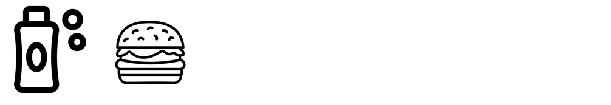

0.5143

1– <20

4-Cumylphenol

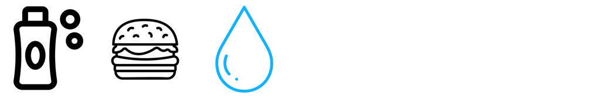

0.7418

20– <100

Acrylamide

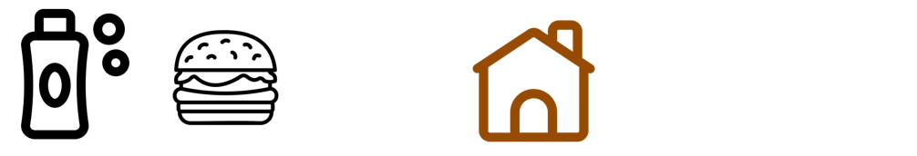

0.6259

500– <750

Acrylonitrile

5.36

1000– <5000

Di(2-ethylhexyl) phthalate

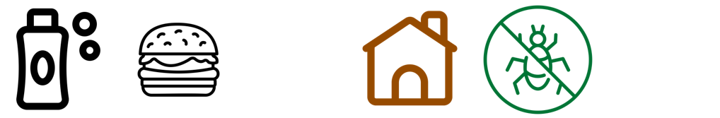

0.4546

10– <50

Dichloromethane

0.321

100– <250

Dimethyl isophthalate

2.089

1– <20

Ethanol

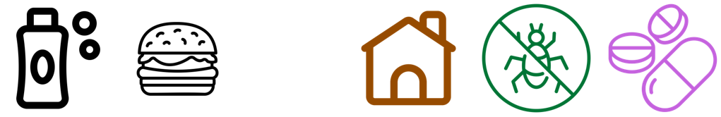

26470

100000– <110000

Ethylene oxide

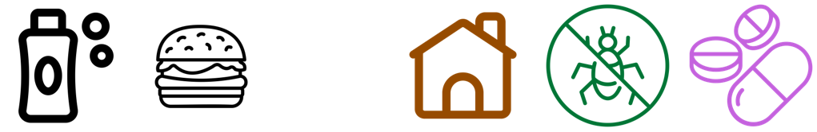

1.492

5000– <10000

Isoprene

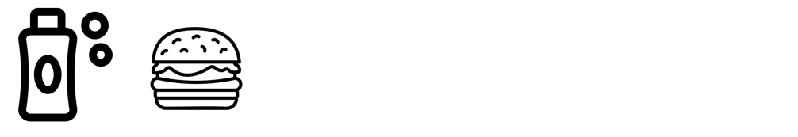

0.3138

100– <250

Methyl dihydrojasmonate

0.1256

1– <20

N,N-Dimethyloctylamine

0.1663

1– <20

Octadecanoic acid

2.551

250– <500

Styrene

0.3705

10000– <20000

Tetrachloroethylene

0.2883

250– <500

Triphenylborane

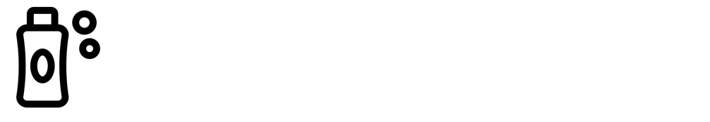

0.1564

1– <20

Tris(2-ethylhexyl) trimellitate

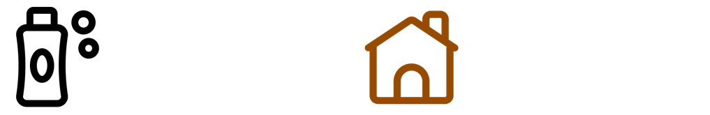

0.3562

50– <100

Vinyl chloride

1.019

10000– <20000

Vinyl fluoride

0.5703

1– <20

p-Cresol

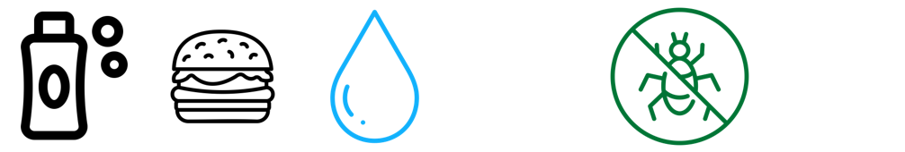

1.522

10– <50